# Reproducible Research: Peer Assessment 1

### For data processing we will use next parameters and libraries

```r
Sys.setlocale("LC_ALL", "English_United Kingdom")
library(plyr)
library(dplyr)
library(ggplot2)
library(lattice)
```

## Loading and preprocessing the data

### We work in specific working directory

```r
setwd("C:/RProjects/RepData_PeerAssessment1")
DataActivity <- read.csv("activity.csv")
head(DataActivity)
```

```
##   steps       date interval
## 1    NA 2012-10-01        0
## 2    NA 2012-10-01        5
## 3    NA 2012-10-01       10
## 4    NA 2012-10-01       15
## 5    NA 2012-10-01       20
## 6    NA 2012-10-01       25
```

## First question: What is mean total number of steps taken per day?

### 1.Calculate the total number of steps taken per day

```r
DataActivityDAY <- ddply(DataActivity, .(date), summarise, steps = sum(steps, na.rm = T))
head(DataActivityDAY)
```

```
##         date steps
## 1 2012-10-01     0
## 2 2012-10-02   126
## 3 2012-10-03 11352
## 4 2012-10-04 12116
## 5 2012-10-05 13294
## 6 2012-10-06 15420
```

### 2. Make a histogram of the total number of steps

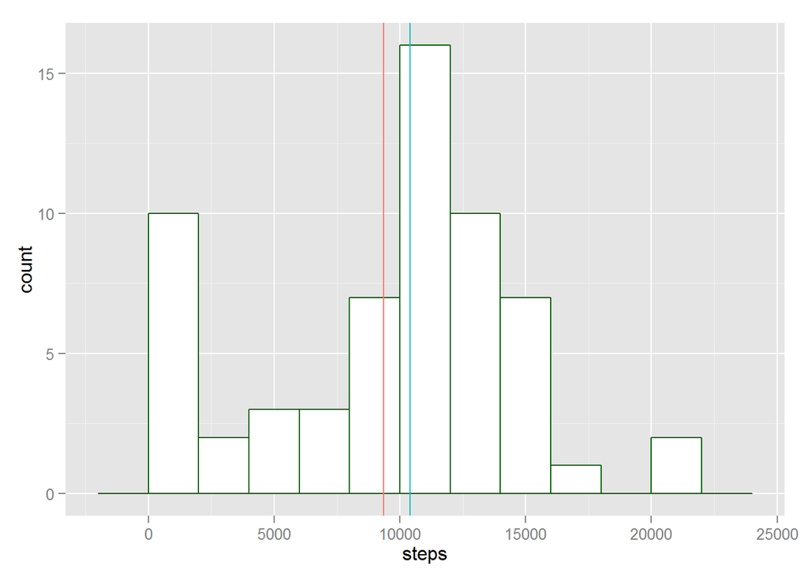

```r
ggplot(DataActivityDAY, aes(steps)) +
  geom_histogram(colour = "darkgreen", fill = "white", binwidth = 2000) +
  geom_vline(aes(xintercept = median(steps), color="#dfc27d")) +
  geom_vline(aes(xintercept = mean(steps), color="#80cdc1"))
```

### 3. Calculate and report the median and mean total number of steps taken per day

```r
median(DataActivityDAY$steps)
```

```
## [1] 10395
```

```r
mean(DataActivityDAY$steps)
```

```
## [1] 9354.23
```

## Second question:What is the average daily activity pattern?

### In first, create a data frame with the intervals and the mean of steps per interval across al days

```r
DataActivityAVG <- ddply(DataActivity, .(interval), summarise, AvgSteps = mean(steps, na.rm = T))
```

### 1. Make a time series plot of the 5-minute interval and the average number of steps taken, averaged across all days

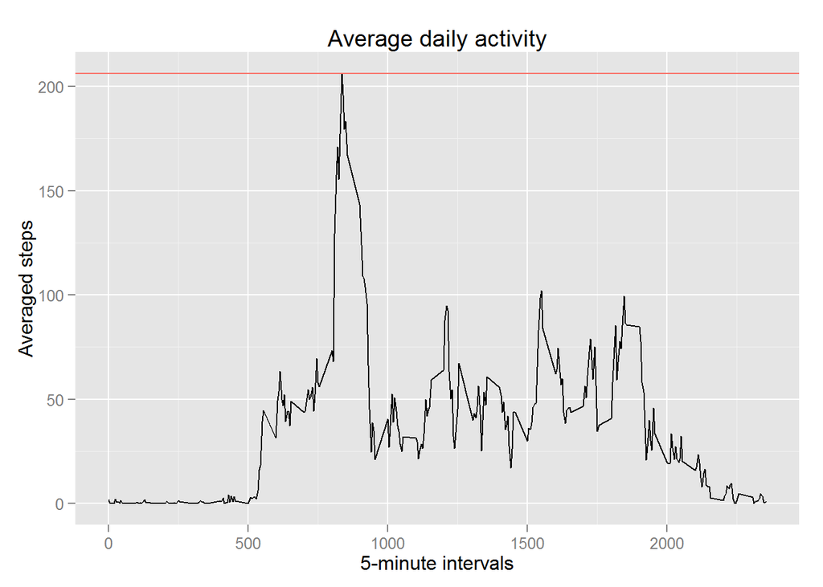

```r
ggplot(DataActivityAVG, aes(interval, AvgSteps)) +
  geom_line() +
  ggtitle("Average daily activity") +
  xlab("5-minute intervals") +
  ylab("Averaged steps") +
  geom_hline(aes(yintercept = max(AvgSteps), color="#dfc27d"))
```

### 2.Which 5-minute interval, on average across all the days in the dataset, contains the maximum number of steps?

```r
MaxSteps <- summarise(DataActivityAVG, max(AvgSteps))
DataActivityAVG[DataActivityAVG$AvgSteps==MaxSteps$`max(AvgSteps)`, ]$interval
```

```
## [1] 835
```